# P8131_HW3

2023-03-02

### QUESTION 1

#### (a) Fit a prospective model.

The two variables are age(continuous) and alcohol consumption(binomial), the outcome is diseased(case) or undiseased(control)(binomial).

```r
cancer =
  data.frame(
    age = rep(c(25, 35, 45, 55, 65, 75), 2),
    al_con = c(rep('0-79',6), rep('80+', 6)),
    case = c(0, 5, 21, 34, 36, 8, 1, 4, 25, 42, 19, 5),
    control = c(106, 164, 138, 139, 88, 31, 9, 26, 29, 27, 18, 0))
cancer
```

```
##    age al_con case control
## 1   25   0-79    0     106
## 2   35   0-79    5     164
## 3   45   0-79   21     138
## 4   55   0-79   34     139
## 5   65   0-79   36      88
## 6   75   0-79    8      31
## 7   25    80+    1       9
## 8   35    80+    4      26
## 9   45    80+   25      29
## 10  55    80+   42      27
## 11  65    80+   19      18
## 12  75    80+    5       0
```

```r
logit_retro = glm(cbind(case, control)~ al_con + age, family = binomial(link='logit'), data = cancer)
summary(logit_retro)
```

```
##
## Call:
## glm(formula = cbind(case, control) ~ al_con + age, family = binomial(link = "logit"),
##     data = cancer)
##
## Deviance Residuals:
##      Min        1Q    Median        3Q       Max
## -2.59974  -1.72957   0.06822   1.19015   1.50808
##
## Coefficients:
##              Estimate Std. Error z value Pr(>|z|)
## (Intercept) -5.023449   0.418224 -12.011   <2e-16 ***
## al_con80+    1.780000   0.187086   9.514   <2e-16 ***
## age          0.061579   0.007291   8.446   <2e-16 ***
## ---
## Signif. codes:  0 '***' 0.001 '**' 0.01 '*' 0.05 '.' 0.1 ' ' 1
##
## (Dispersion parameter for binomial family taken to be 1)
##
##     Null deviance: 211.608  on 11  degrees of freedom
## Residual deviance:  31.932  on  9  degrees of freedom
## AIC: 78.259
##
## Number of Fisher Scoring iterations: 4
```

```r
p_v = 1-pchisq(logit_retro$deviance, 24-3)
```

#### (b) Compare two models

When the odds ratio relating alcohol consumption is 1, the coefficient relating to alcohol is 0. And when different age groups have different odds, age groups should be dummy variables with different coefficients. Therefore, we first mutate age into a factor variable, then build two models with or without alcohol consumption.

```r
cancer$age = as.factor(cancer$age)

M0 = M1 = glm(cbind(case, control)~ age, family = binomial(link='logit'), data = cancer)
M1 = glm(cbind(case, control)~ age + al_con, family = binomial(link='logit'), data = cancer)
summary(M0)
```

```
##
## Call:
## glm(formula = cbind(case, control) ~ age, family = binomial(link = "logit"),
##     data = cancer)
##
## Deviance Residuals:
##    Min      1Q  Median      3Q     Max
## -3.477  -1.299   0.368   2.481   5.028
##
## Coefficients:
##             Estimate Std. Error z value Pr(>|z|)
## (Intercept)   -4.745      1.004  -4.725 2.31e-06 ***
## age35          1.695      1.061   1.598 0.110006
## age45          3.456      1.018   3.394 0.000688 ***
## age55          3.964      1.014   3.910 9.24e-05 ***
## age65          4.089      1.018   4.017 5.90e-05 ***
## age75          3.876      1.057   3.666 0.000246 ***
## ---
## Signif. codes:  0 '***' 0.001 '**' 0.01 '*' 0.05 '.' 0.1 ' ' 1
##
## (Dispersion parameter for binomial family taken to be 1)
##
##     Null deviance: 211.608  on 11  degrees of freedom
## Residual deviance:  90.563  on  6  degrees of freedom
## AIC: 142.89
##
## Number of Fisher Scoring iterations: 6
```

```r
summary(M1)
```

```
##
## Call:
## glm(formula = cbind(case, control) ~ age + al_con, family = binomial(link = "logit"),
##     data = cancer)
##
## Deviance Residuals:
##        1         2         3         4         5         6         7         8
## -1.16129   0.04747  -0.11628  -0.35391   0.96513  -0.67850   0.96641  -0.05538
##        9        10        11        12
##  0.13652   0.45905  -1.59342   2.11053
##
## Coefficients:
##             Estimate Std. Error z value Pr(>|z|)
## (Intercept)  -5.0543     1.0094  -5.007 5.53e-07 ***
## age35         1.5423     1.0659   1.447 0.147916
## age45         3.1988     1.0232   3.126 0.001770 **
## age55         3.7135     1.0185   3.646 0.000266 ***
## age65         3.9669     1.0231   3.877 0.000106 ***
## age75         3.9622     1.0650   3.720 0.000199 ***
## al_con80+     1.6699     0.1896   8.807  < 2e-16 ***
## ---
## Signif. codes:  0 '***' 0.001 '**' 0.01 '*' 0.05 '.' 0.1 ' ' 1
##
## (Dispersion parameter for binomial family taken to be 1)
##
##     Null deviance: 211.608  on 11  degrees of freedom
## Residual deviance:  11.041  on  5  degrees of freedom
## AIC: 65.369
##
## Number of Fisher Scoring iterations: 5
```

M0 and M1 are nested with M1 being the larger model. For model selection, we use deviance analysis.

```r
del_dev = M0$deviance - M1$deviance
p_v = 1 - pchisq(del_dev, 1)
p_v
```

```
## [1] 0
```

According to the deviance analysis assuming that M0 is true, our p_value is less than 0.05, indicating that we reject the smaller model M0 and M1 is better.

### QUESTION 2

#### (a) Fit a logistic model

```r
ger =
  data.frame(
    seed = c(rep('O.75', 11), rep('O.73', 10)),
    media = c(rep('Bean', 5), rep('Cucm', 6), rep('Bean', 5), rep('Cucm', 5)),
    germed = c(10, 23, 23, 26, 17, 5, 53, 55, 32, 46, 10, 8, 10, 8, 23, 0, 3, 22, 15, 32, 3),
    num = c(39, 62, 81, 51, 39, 6, 74, 72, 51, 79, 13, 16, 30, 28, 45, 4, 12, 41, 30, 51, 7))
logit = glm(cbind(germed, num-germed) ~ seed+media, family = binomial(link='logit'), data = ger)
summary(logit)
```

```
##
## Call:
## glm(formula = cbind(germed, num - germed) ~ seed + media, family = binomial(link = "logit"),
##     data = ger)
##
## Deviance Residuals:
##     Min       1Q   Median       3Q      Max
## -2.3919  -0.9949  -0.3744   0.9831   2.4766
##
## Coefficients:
##             Estimate Std. Error z value Pr(>|z|)
## (Intercept)  -0.7005     0.1507  -4.648 3.36e-06 ***
## seedO.75      0.2705     0.1547   1.748   0.0804 .
## mediaCucm     1.0647     0.1442   7.383 1.55e-13 ***
## ---
## Signif. codes:  0 '***' 0.001 '**' 0.01 '*' 0.05 '.' 0.1 ' ' 1
##
## (Dispersion parameter for binomial family taken to be 1)
##
##     Null deviance: 98.719  on 20  degrees of freedom
## Residual deviance: 39.686  on 18  degrees of freedom
## AIC: 122.28
##
## Number of Fisher Scoring iterations: 4
```

```r
p_v = 1-pchisq(logit$deviance, 21-3)
```

Here we fitted a logistic model of germination rates using X1=type_of_seed and X2=type_of_media. The intercept β0=-0.70 while β1=0.27, β2=1.06. Indicating that the unit change of log odds when seed changes from O.a73 to O.a75 holding media fixed is 0.27, and when media changes from bean to cucumber holding type of seeds fixed is 1.06. The possibility of germination is higher with O.a75 seed and cucumber media. But according to Pearson Chi-square test statistic, this is not a good fit.

#### (b) Check for dispersion.

```r
G.stat = sum(residuals(logit, type='pearson')^2)
phi = G.stat/(21-3)
phi
```

```
## [1] 2.128368
```

```r
tilde.phi = logit$deviance/logit$df.residual
tilde.phi
```

```
## [1] 2.204772
```

The p-value from Pearson Chi-square test indicates bad model-fitting and there is dispersion. The estimate of dispersion parameter is 2.1283678.

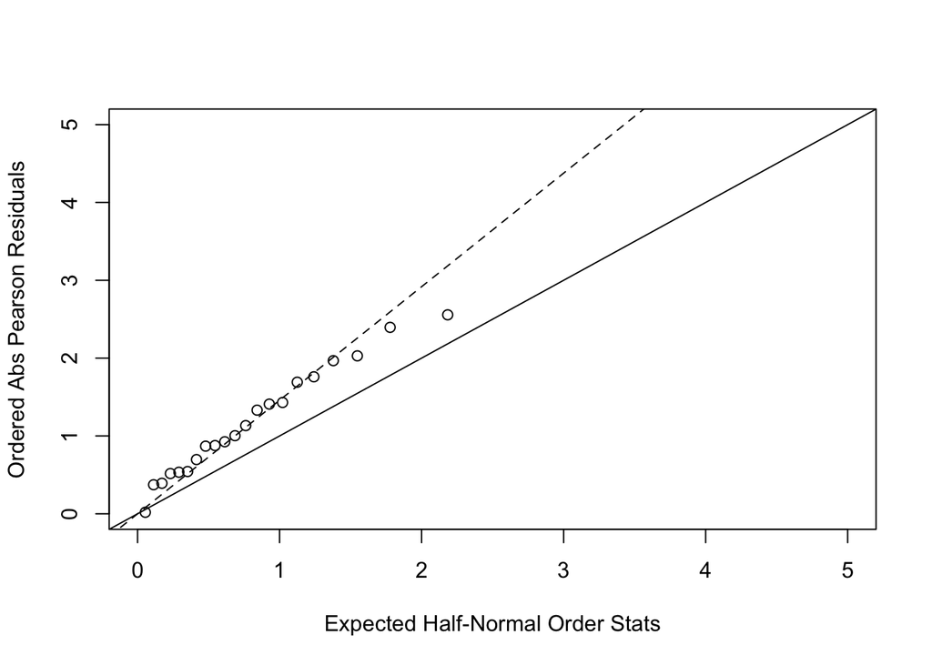

```r
res=residuals(logit,type='pearson')
plot(qnorm((21+1:21+0.5)/(2*21+1.125)),sort(abs(res)),
     xlab='Expected Half-Normal Order Stats',
     ylab='Ordered Abs Pearson Residuals',
     ylim=c(0,5),
     xlim=c(0,5))
abline(a=0,b=1)
abline(a=0,b=sqrt(phi),lty=2)
```

The updated model with dispersion is:

```r
summary(logit, dispersion=phi)
```

```
##
## Call:
## glm(formula = cbind(germed, num - germed) ~ seed + media, family = binomial(link = "logit"),
##     data = ger)
##
## Deviance Residuals:
##     Min       1Q   Median       3Q      Max
## -2.3919  -0.9949  -0.3744   0.9831   2.4766
##
## Coefficients:
##             Estimate Std. Error z value Pr(>|z|)
## (Intercept)  -0.7005     0.2199  -3.186  0.00144 **
## seedO.75      0.2705     0.2257   1.198  0.23081
## mediaCucm     1.0647     0.2104   5.061 4.18e-07 ***
## ---
## Signif. codes:  0 '***' 0.001 '**' 0.01 '*' 0.05 '.' 0.1 ' ' 1
##
## (Dispersion parameter for binomial family taken to be 2.128368)
##
##     Null deviance: 98.719  on 20  degrees of freedom
## Residual deviance: 39.686  on 18  degrees of freedom
## AIC: 122.28
##
## Number of Fisher Scoring iterations: 4
```